# PhantomPurgeR: Vignette

Rick Farouni

2020-01-09

```r
library(PhantomPurgeR)
```

### Read filepaths of all h5 files found in the data input folder

The data directory *input_dir* is the filepath of the folder that contains all the molecule_info.h5 files of all the samples that were multiplexed on the same lane. The files can be renamed by sample names (e.g. sample_name.h5) before being loaded or after as shown below.

```r
input_dir <- "~/Documents/hiseq4000"
```

```r
samples_filepaths <- get_h5_filenames(input_dir)
samples_filepaths
```

```
##                                         A1
## "/home/rfarouni/Documents/hiseq4000/A1.h5"
##                                         A2
## "/home/rfarouni/Documents/hiseq4000/A2.h5"
##                                         B1
## "/home/rfarouni/Documents/hiseq4000/B1.h5"
##                                         B2
## "/home/rfarouni/Documents/hiseq4000/B2.h5"
##                                         C1
## "/home/rfarouni/Documents/hiseq4000/C1.h5"
##                                         C2
## "/home/rfarouni/Documents/hiseq4000/C2.h5"
##                                         D1
## "/home/rfarouni/Documents/hiseq4000/D1.h5"
##                                         D2
## "/home/rfarouni/Documents/hiseq4000/D2.h5"
```

Change the names of the samples if the filenames are too long.

```r
#names(samples_filepaths) <- paste0("s", 1:length(samples_filepaths))
```

# Run PhantomPurgeR workflow

The workflow can be run in four stages or alternatively all steps can all be run at once using the *phantom_purger* function.

```r
#out <- phantom_purger(samples, torc=3, return_readcounts=FALSE, return_discarded=FALSE)
```

## (1) Read data

```r
out <- read10xMolInfoSamples(samples_filepaths)
```

```
## Loading samples data from molecule_info.h5 files produced by 10X Genomics CellRanger software: 31.511 sec elapsed
```

## (2) Join and merge data

```r
out <- join_data(out)
```

```
## Joining data. Step 1: creating read counts datatables from lists: 0.009 sec elapsed
## Joining data. Step 2: joining and merging datatables for all samples keyed by cell, umi, and gene: 50.894 sec elapsed
## Joining data. Step 3: creating an outcome variable for each row: 212.291 sec elapsed
```

### Read counts datatable

```r
out$read_counts
```

```
##                       cell  gene     umi A1 A2 B1 B2 C1 C2 D1 D2
##        1: AAACCTGAGAAACCAT  9004  468967 21  0  0  0  0  0  0  0
##        2: AAACCTGAGAAACCAT 22877  410924  1  0  0  0  0  0  0  0
##        3: AAACCTGAGAAACCAT  9800   43591  1  0  0  0  0  0  0  0
##        4: AAACCTGAGAAACCAT  3756 1012503 13  0  0  0  0  0  0  0
##        5: AAACCTGAGAAACCAT  7009  621442 12  0  0  0  0  0  0  0
##       ---
## 53636691: TTTGTCATCTTGTCAT 22857 1022717  0  0  0  0  0  0  0  1
## 53636692: TTTGTCATCTTGTCAT 19753  241763  0  0  0  0  0  0  0 20
## 53636693: TTTGTCATCTTGTTTG 20921  676602  0  0  0  0  0  0  0  1
## 53636694: TTTGTCATCTTGTTTG 19719  717054  0  0  0  0  0  0  0  1
## 53636695: TTTGTCATCTTGTTTG 19546  171242  0  0  0  0  0  0  0  3
##                    outcome
##        1: 21,0,0,0,0,0,0,0
##        2:  1,0,0,0,0,0,0,0
##        3:  1,0,0,0,0,0,0,0
##        4: 13,0,0,0,0,0,0,0
##        5: 12,0,0,0,0,0,0,0
##       ---
## 53636691:  0,0,0,0,0,0,0,1
## 53636692: 0,0,0,0,0,0,0,20
## 53636693:  0,0,0,0,0,0,0,1
## 53636694:  0,0,0,0,0,0,0,1
## 53636695:  0,0,0,0,0,0,0,3
```

## (3) Estimate sample index hopping rate

```r
out <- estimate_hopping_rate(out)
```

```
## Estimating SIHR. Step 1: creating outcome counts datatable: 12.977 sec elapsed
## Estimating SIHR. Step 2: creating chimera counts datatable: 0.053 sec elapsed
## Estimating SIHR. Step 3: fitting GLM: 0.056 sec elapsed
## Estimating SIHR. Step 4: computing summary statistics: 1.111 sec elapsed
```

### Estimates

```r
out$glm_estimates
```

```
## # A tibble: 1 x 6
##   max_r  phat phat_low phat_high    SIHR   SBIHR
##   <int> <dbl>    <dbl>     <dbl>   <dbl>   <dbl>
## 1  3744 0.991    0.991     0.991 0.00866 0.00958
```

#### Summary statistics of the joined read counts datatable

```r
out$summary_stats$summary_estimates
```

```
## # A tibble: 1 x 7
##     n_reads   n_cugs    n_pm      u       g   RMR p_chimeras
##       <int>    <dbl>   <dbl>  <dbl>   <dbl> <dbl>      <dbl>
## 1 626168518 53636695 4460074 0.0817 0.00147  11.7     0.0710
```

p_chimeras is the proportion CUGs that are chimeric. g is the estimated proportion of fugue molecules and u is the molecule inflation factor such that n_cugs x u would give the number of non-fugue phantom molecules. The estimated total number of phantom molecules present in the dataset is given by n_pm=n_cugs x (u+g).

#### Marginal summary statistics

```r
out$summary_stats$marginal
```

```
## # A tibble: 8 x 6
##   sample  n_reads prop_reads n_molecs p_molecs   RMR
##   <chr>     <dbl>      <dbl>    <int>    <dbl> <dbl>
## 1 A1     81735236      0.131  7026743   0.121  11.6
## 2 A2     82030289      0.131  9592019   0.165   8.55
## 3 B1     80278882      0.128  1820293   0.0314 44.1
## 4 B2     87690082      0.140  1751340   0.0302 50.1
## 5 C1     76298833      0.122 10456528   0.180   7.30
## 6 C2     75477112      0.121 18646495   0.321   4.05
## 7 D1     66843761      0.107  6564850   0.113  10.2
## 8 D2     75814323      0.121  2159758   0.0372 35.1
```

## (4) Purge phantom molecules

Call garbage collection first

```r
gc()
```

```
##             used   (Mb) gc trigger    (Mb)   max used    (Mb)
## Ncells   6540555  349.4   11033891   589.3   11033891   589.3
## Vcells 605436388 4619.2 1923031191 14671.6 1923031191 14671.6
```

Set the trade-off ratio cost cutoff (torc). The parameter torc represents the number of real molecules one is willing to incorrectly discard in order to correctly purge one phantom molecule. Since discarding a large proportion of the data is undesirable, reasonable values of torc are expected to be within the range of 1-5.

```r
out <- purge_phantoms(out,
                      torc=3,
                      return_readcounts=FALSE,
                      return_discarded=FALSE)
```

```
## Purging phantom molecules. Step 1: reassigning hopped reads: 6.666 sec elapsed
## Purging phantom molecules. Step 2: getting observed tor threshold below user-provided cutoff: 0.066 sec elapsed
## Purging phantom molecules. Step 3: marking retained observations in read counts table: 5.887 sec elapsed
## Purging phantom molecules. Step 4: creating sparse count matrices of cleaned and discarded data: 18.456 sec elapsed
```

```r
out$summary_stats$cutoff_dt
```

```
## # A tibble: 5 x 13
##   approach outcome     s     qr     n    tor     o     FP     FN     TP     TN
##   <chr>    <chr>   <int>  <dbl> <int>  <dbl> <dbl>  <dbl>  <dbl>  <dbl>  <dbl>
## 1 torc_be… 0,1,2,…     3  0.107     1   6.24 0.998 6.92e4 114007 5.34e7 4.39e6
## 2 discard… 0,0,1,…     3  0.111 99899   2.96 1.000 8.03e4  25186 5.35e7 4.38e6
## 3 torc_af… 0,1,0,…     8  0.111     1   2.96 1.000 8.03e4  25185 5.35e7 4.38e6
## 4 no_disc… 0,1,0,…     5  0.563     6 NaN    1.    8.63e4   7546 5.36e7 4.37e6
## 5 no_purg… <NA>       NA NA        NA  NA    1.08  4.46e6      0 5.36e7 0.
## # … with 2 more variables: FPm <dbl>, FNm <dbl>
```

The row discard_torc shows the outcome whose qr value is the maximum allowed. Reads corresponding to outcomes with greater qr values are discarded. no_discarding corresponds to retaining all reassigned reads and no_purging corresponds to keeping the data as it is.

```r
out$summary_stats$purge_summary
```

```
## # A tibble: 8 x 6
##   sample umi_total retained purged_real purged_phantom phantom_prop
##   <chr>      <int>    <int>       <int>          <int>        <dbl>
## 1 A1       7026743  6789262         536         236945       0.0337
## 2 A2       9592019  9376805        2272         212942       0.0222
## 3 B1       1820293   246010        1009        1573274       0.864
## 4 B2       1751340   307244        1118        1442978       0.824
## 5 C1      10456528 10227585        3989         224954       0.0215
## 6 C2      18646495 18410983       11803         223709       0.0120
## 7 D1       6564850  6357450        1584         205816       0.0314
## 8 D2       2159758  1897746        1299         260713       0.121
```

```r
str(out$umi_counts$retained$A1)
```

```
## Formal class 'dgCMatrix' [package "Matrix"] with 6 slots
##   ..@ i       : int [1:1948968] 3755 4003 6120 7008 8996 9003 9422 9799 10531 12313 ...
##   ..@ p       : int [1:151148] 0 16 17 22 29 37 38 53 54 56 ...
##   ..@ Dim     : int [1:2] 27998 151147
##   ..@ Dimnames:List of 2
##   .. ..$ : chr [1:27998(1d)] "ENSMUSG00000051951" "ENSMUSG00000089699" "ENSMUSG00000102343" "ENSMUSG00000025900" ...
##   .. ..$ : chr [1:151147] "AAACCTGAGAAACCAT" "AAACCTGAGAAACGAG" "AAACCTGAGAACTCGG" "AAACCTGAGAAGCCCA" ...
##   ..@ x       : num [1:1948968] 1 1 1 1 1 1 1 1 1 1 ...
##   ..@ factors : list()
```

#### Outcome counts datatable

The datatable is ordered in descending order of qr, the posterior probability of incorrectly assigning s as the inferred sample of origin. n is the number of CUGs with the corresponding outcome and p_outcome is the observed marginal probability of that outcome.

```r
out$outcome_counts
```

```
## # A tibble: 187,567 x 17
##    outcome     s    qr     r     n     o    FP    FN     TP     TN   FPm   FNm
##    <chr>   <int> <dbl> <int> <int> <dbl> <dbl> <dbl>  <dbl>  <dbl> <dbl> <dbl>
##  1 0,1,0,…     5 0.563     3     6 1.    86289  7546 5.36e7 4.37e6     0     0
##  2 1,1,0,…     5 0.556     3     2 1.000 86286  7548 5.36e7 4.37e6     3     2
##  3 0,0,1,…     4 0.549     2   290 1.000 86285  7549 5.36e7 4.37e6     4     3
##  4 0,1,2,…     4 0.543     6     1 1.000 86125  7680 5.36e7 4.37e6   164   134
##  5 1,1,1,…     2 0.540     5     1 1.000 86125  7680 5.36e7 4.37e6   164   134
##  6 1,1,0,…     2 0.535     3     1 1.000 86124  7681 5.36e7 4.37e6   165   135
##  7 0,0,2,…     4 0.527     5     1 1.000 86124  7681 5.36e7 4.37e6   165   135
##  8 1,1,2,…     4 0.513     6     1 1.000 86123  7682 5.36e7 4.37e6   166   136
##  9 1,0,0,…     7 0.512     3     3 1.000 86123  7682 5.36e7 4.37e6   166   136
## 10 2,0,0,…     1 0.499     5     1 1.000 86121  7684 5.36e7 4.37e6   168   138
## # … with 187,557 more rows, and 5 more variables: tor <dbl>, retain <lgl>,
## #   qs <dbl>, FPp <dbl>, p_outcome <dbl>
```

## Make diagnostic plots

```r
dataset_name <- "Hiseq4000"
plots <- make_plots(out, dataset_name, x_lim = 150, legend_rel_width=0.2)
```

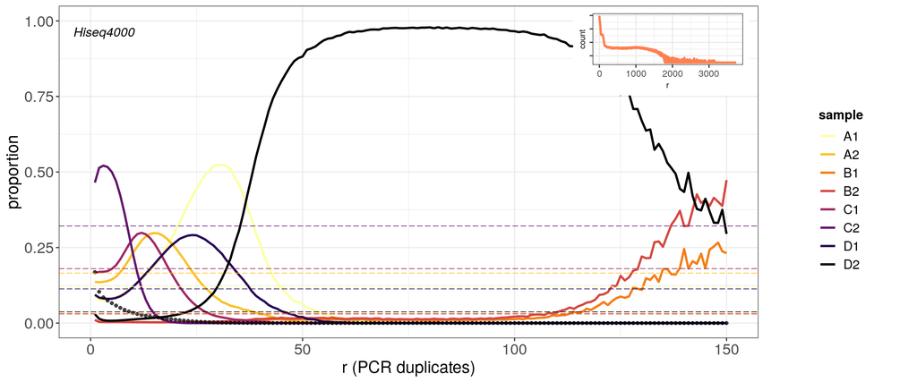

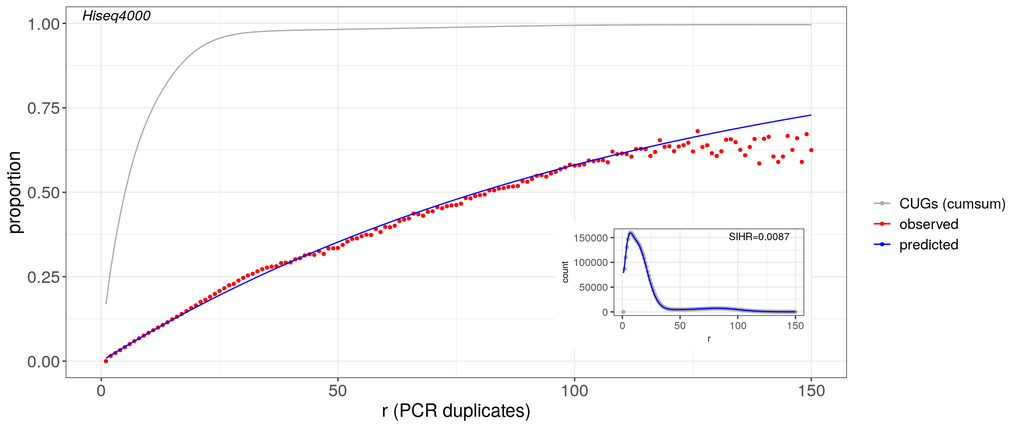

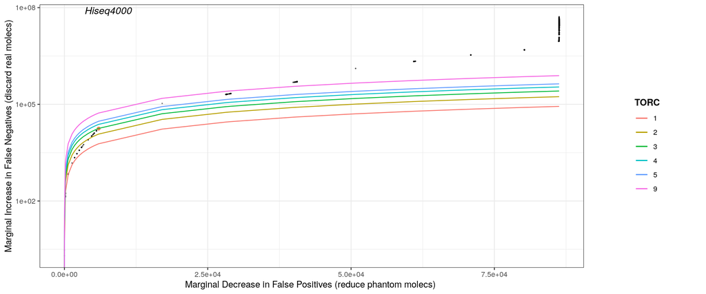

```r
plots
```